# Step 1: Import Required Libraries

These Python libraries are needed for data handling, visualization, machine learning, and evaluation.

```python
import pandas as pd
import numpy as np
import matplotlib.pyplot as plt
import seaborn as sns
from sklearn.ensemble import RandomForestRegressor
from sklearn.model_selection import train_test_split
from sklearn.metrics import mean_absolute_error, r2_score
```

# pandas and numpy for data manipulation

# matplotlib and seaborn for visualizing data

# sklearn methods for modeling and evaluating crop yield prediction

# Step 2: Create Synthetic Dataset

Simulate crop features and yields to mimic real-world data

```python
np.random.seed(42)  # For reproducibility
num_samples = 500

soil_moisture = np.random.uniform(0.1, 0.8, num_samples)  # Soil moisture level
temperature = np.random.uniform(10, 35, num_samples)     # Temperature in Celsius
rainfall = np.random.uniform(0, 200, num_samples)        # Rainfall in mm
ndvi = np.random.uniform(0.2, 0.9, num_samples)           # Vegetation index (NDVI)
crop_type = np.random.choice(["Wheat", "Maize", "Rice"], num_samples)  # Crop variety
season = np.random.choice(["Kharif", "Rabi"], num_samples)             # Growing season
```

# We generate 500 data points with realistic ranges for different crop yield influencing factors.

# Step 3: Generate Crop Yield with Noise

Create a target variable Yield based on features with some noise to simulate variability.

```python
yield_ = (soil_moisture * 50 + temperature * 2 + rainfall * 0.3 + ndvi * 40 +
          np.where(crop_type == "Wheat", 10, 0) + np.where(crop_type == "Maize", 20, 0) +
          np.where(season == "Kharif", 5, 0) + np.random.normal(0, 5, num_samples))
```

Yield grows with soil moisture, temperature, rainfall, and NDVI

Additional increments based on crop type and season

Added random noise to simulate natural variation

# Step 4: Create DataFrame

Combine all features and yield into a DataFrame for analysis.

```python
data = pd.DataFrame({
    "Soil_Moisture": soil_moisture,
    "Temperature": temperature,
    "Rainfall": rainfall,
    "NDVI": ndvi,
    "Crop_Type": crop_type,
    "Season": season,
    "Yield": yield_
})
```

# Step 5: Encode Categorical Variables

Convert categorical columns Crop_Type and Season to numeric format using one-hot encoding

```python
data_encoded = pd.get_dummies(data, columns=["Crop_Type", "Season"], drop_first=True)
```

This allows ML models to work with these features by creating binary indicator columns.

# Step 6: View Descriptive Statistics

Get statistical summary of your dataset to understand feature distributions.

```python
print(data.describe())
```

```
       Soil_Moisture  Temperature    Rainfall        NDVI       Yield
count     500.000000   500.000000  500.000000  500.000000  500.000000
mean        0.448993    22.048785  103.511624    0.547534  131.690620
std         0.209082     7.137336   59.438587    0.200907   28.336857
min         0.103543    10.115801    0.987996    0.202253   47.673949
25%         0.268896    15.727481   48.245610    0.368752  113.388307
50%         0.459215    21.795539  107.947667    0.556224  131.195388
75%         0.629287    28.158421  155.468752    0.716163  151.237365
max         0.795075    34.992942  199.882745    0.898843  204.336240
```

Shows count, mean, std deviation, min, max, and quartiles for numeric features including Yield

# Step 7: Visualize Data Distributions and Comparisons

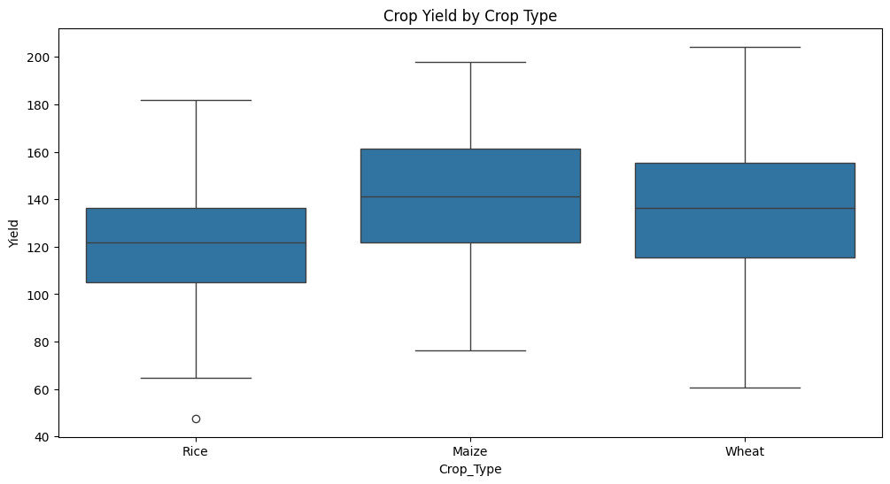

```python
plt.figure(figsize=(12, 6))
sns.boxplot(x="Crop_Type", y="Yield", data=data)
plt.title("Crop Yield by Crop Type")
plt.show()
```

Boxplots to compare yield variations across crop types.

# Yield by Season

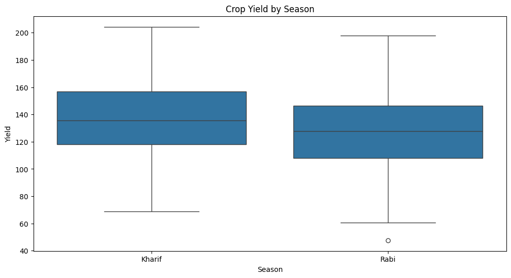

```python
plt.figure(figsize=(12, 6))
sns.boxplot(x="Season", y="Yield", data=data)
plt.title("Crop Yield by Season")
plt.show()
```

Boxplots to compare yield differences between seasons.

# Feature Correlation Heatmap

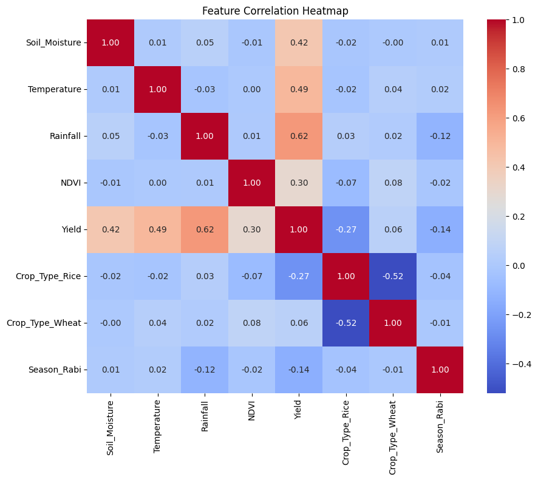

```python
plt.figure(figsize=(10, 8))
sns.heatmap(data_encoded.corr(), annot=True, fmt='.2f', cmap='coolwarm')
plt.title("Feature Correlation Heatmap")
plt.show()
```

Shows correlation strengths and directions between numerical features and yield.

# Step 8: Prepare Data for Modeling

Separate features and target, then split into training and test sets.

```python
X = data_encoded.drop(columns=["Yield"])
y = data_encoded["Yield"]

X_train, X_test, y_train, y_test = train_test_split(X, y, test_size=0.2, random_state=42)
```

# Step 9: Train Random Forest Regression Model

Fit a Random Forest model to predict crop yield.

```python
model = RandomForestRegressor(random_state=42)
model.fit(X_train, y_train)
```

```
RandomForestRegressor(random_state=42)
```

# Step 10: Evaluate Model Performance

Predict yields on test data and calculate error metrics.

```python
y_pred = model.predict(X_test)

mae = mean_absolute_error(y_test, y_pred)
r2 = r2_score(y_test, y_pred)

print(f"Mean Absolute Error: {mae:.2f}")
print(f"R-squared: {r2:.2f}")
```

```
Mean Absolute Error: 8.26
R-squared: 0.85
```

MAE measures average prediction error

R-squared quantifies variance explained by the model

# Step 11: Analyze Feature Importance

```
           Feature  Importance
2         Rainfall    0.420793
1      Temperature    0.265797
0    Soil_Moisture    0.158737
3             NDVI    0.101603
4   Crop_Type_Rice    0.043196
6      Season_Rabi    0.005053
5  Crop_Type_Wheat    0.004821
```

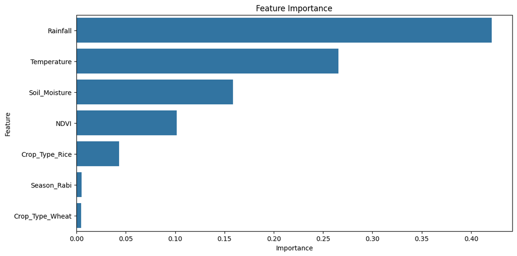

```python
importances = model.feature_importances_
feature_names = X.columns

importance_df = pd.DataFrame({'Feature': feature_names, 'Importance': importances}).sort_values(by='Importance', ascending=False)
print(importance_df)

plt.figure(figsize=(12, 6))
sns.barplot(data=importance_df, x='Importance', y='Feature')
plt.title('Feature Importance')
plt.show()
```

# In conclusion,

Machine learning models, particularly ensemble methods like Random Forest, have demonstrated strong potential for accurately predicting crop yields based on features such as soil moisture, temperature, rainfall, vegetation indices, crop type, and season. These models effectively capture complex nonlinear relationships between environmental and crop variables, enabling robust yield forecasts that can assist farmers and agricultural planners in optimizing resource allocation, managing risks, and improving decision-making.

Descriptive statistics and visualizations help reveal important trends and feature distributions, while feature importance analysis highlights which variables are most influential in predicting yields. Although challenges such as regional and seasonal variability remain, advancements in sensing technologies, remote sensing data integration, and machine learning algorithms offer promising pathways toward cost-effective, scalable, and timely yield prediction.

This approach is valuable for improving agricultural productivity and sustainability, ultimately contributing to food security in the face of climate change and growing global demand. Future work may involve integrating multi-source data, deploying automated machine learning pipelines, and adapting models for diverse geographic and crop-specific conditions to further enhance predictive accuracy and practical impact.

Overall, the use of machine learning in crop yield prediction represents a transformative step toward smarter, data-driven agriculture that supports efficient, sustainable farming practices